# pyMódulo 03

Curso IE0217 Estructuras abstractas y algoritmos para ingeniería - UCR

Profesor Freddy Rojas Ch.

1/26/2021

# Lenguaje Python 3 Módulo 3

Este es el tercer módulo de programación con Python 3.

## Funciones en Python

La construcción de funciones se realiza con la sentencia *def* seguida de un nombre para la función y una lista de parámetros. Mantiene la estrucutura tabular del resto del leguaje.

El primer ejemplo se va a hacer construyendo una función de suma de dos argumentos.

```python
# FUNCIONES:

# def nombre_funcion(parametro_0, ... , parametro_n):
#    Desarrollo de la función tabulado.
#    return valor

# Función suma(x,y)

# Se define la función
def suma(x,y):
  z = x + y
  return z

# Se hace el llamado a la función
res = suma(30,12)
print(res)
```

```
## 42
```

En el siguiente ejemplo se integra dentro de la función el uso de la impresión de resultados a consola. No se condiera una buena práctica en los lenguajes de progrmaación, cuando se hace de forma aislada. Lo recomendable es que se desarrolle un conjunto de facilidades en un “paquete” o mediante un “objeto” para que aspectos de redireccionamiento de entrada/salida hacia archivos o con interfaces visuales sean más apropiados y consuman menos tiempo en re-implementación.

```python
# Definición de la función imprime_informacion.

def imprime_informacion(usuario):
  print("Contenido de informacion de usuario: " + usuario.title() + "!")

# Invocación
imprime_informacion('jose')
```

```
## Contenido de informacion de usuario: Jose!
```

```python
imprime_informacion('eduardo')
```

```
## Contenido de informacion de usuario: Eduardo!
```

### Funciones con argumentos estáticos

En el siguiente ejemplo la función declarada debe siempre contener TODODS los argumentos al momento de invocarla.

Nótese en el tercer ejemplo que únicamente al asignar los valores con los respectivos nombres, se puede variar el orden de los argumentos

```python
# Definición de una función con parámetros estatícos. No tienen valor por omision y deben aporarse ambos siempre.
def area_triangulo_estica(base,altura):
  area = (base*altura)/2
  return(area)

# Invocación
area_triangulo_estica(3,4)
```

```
## 6.0
```

```python
area_triangulo_estica(base=10, altura=15)
```

```
## 75.0
```

```python
area_triangulo_estica(altura=15, base=10)
```

```
## 75.0
```

### Funciones con argumentos con asignaciones por omisión.

Para generalizar un uso “sobrecargado” de funciones, se deben asociar valores por omisión a los parámetros que pueden ser omitidos en el llamado a una función.

```python
# Valores por defecto en parámetros

def area_triangulo(base=1,altura=1):
  area = (base*altura)/2
  return(area)

# Invocación
area_triangulo(30,15)

# Usa los valores por defecto
```

```
## 225.0
```

```python
area_triangulo(30)
```

```
## 15.0
```

```python
print("++++++++++++++++\n")
```

```
## ++++++++++++++++
```

```python
area_triangulo()
```

```
## 0.5
```

```python
print("++++++++++++++++\n")
```

```
## ++++++++++++++++
```

### Funciones que retornan listas o diccionarios

En estos ejemplos se ilustra la forma en que una función puede devolver varios datos empaquetados mediante una estructura dinámica como una lista o un diccionario.

```python
# Retornando conjuntos con valores
# Retornando un diccionario (Similar a R que se retorna una lista)
def nombre_completo_(nombre, apellido):
  persona = {'Nombre': nombre, 'Apellido': apellido}
  return persona

usuario = nombre_completo_('Juan Mora', 'Fernández')
print(usuario)
```

```
## {'Nombre': 'Juan Mora', 'Apellido': 'Fernández'}
```

```python
def nombre_completo(nombre, apellido, edad=''):
  persona = {'Nombre': nombre, 'Apellido': apellido}
  if edad:
    persona['Edad'] = edad
  return persona

usuario = nombre_completo('Juan Mora', 'Fernández')
print(usuario)
```

```
## {'Nombre': 'Juan Mora', 'Apellido': 'Fernández'}
```

```python
usuario = nombre_completo('Juan Mora', 'Fernández',edad=50)
print(usuario)
```

```
## {'Nombre': 'Juan Mora', 'Apellido': 'Fernández', 'Edad': 50}
```

En el siguiente ejemplo se genera una lista de números impares a partir de un lazo iterativo mediante la sentencia *for* dentro de la función.

```python
def conformacion_lista_impares(datos_impares=0):
  lista=[]
  for i in range(0,datos_impares+1):
    if i % 2 !=0:
      lista.append(i)
  return lista

lista_impares=conformacion_lista_impares(151)
print(lista_impares)
```

```
## [1, 3, 5, 7, 9, 11, 13, 15, 17, 19, 21, 23, 25, 27, 29, 31, 33, 35, 37, 39, 41, 43, 45, 47, 49, 51, 53, 55, 57, 59, 61, 63, 65, 67, 69, 71, 73, 75, 77, 79, 81, 83, 85, 87, 89, 91, 93, 95, 97, 99, 101, 103, 105, 107, 109, 111, 113, 115, 117, 119, 121, 123, 125, 127, 129, 131, 133, 135, 137, 139, 1…
```

### Funciones con sentencias de control internas.

En el ejemplo anterior se mostró el uso de un *for* generando una lista.

En el siguiente ejemplo se termina el número mayor de tres entradas para ilustrar el uso del *if* dentro de una función.

```python
# Ejemplo con if: El mayor entre 3 números
def mayor(A, B, C):
  if (A > B) and (A > C):
    return(A)
  elif (B > A) and (B > C):
    return(B)
  else:
    return(C)

mayor(9,0,2)
```

```
## 9
```

En este otro ejemplo se ve el uso del cálculo de una función a partir de dos ciclos for consecutivos. Se muestra para un valor específico y para una lista de valores. El resultado es de nuevo una lista generada dentro de la lista.

```python
# Ejemplo con for
# construye un vector “v”
# tal que en la entrada k sea una serie dada porr k^2−4.
#  v[k]=k^2−4:
def cvector_f(n):
  # Inicializa un vector con n ceros
  v = []
  for k in range(n):
    v.append(0)
  for k in range(n):
    v[k]=k**2 - 4
  return(v)

cvector_f(9)
```

```
## [-4, -3, 0, 5, 12, 21, 32, 45, 60]
```

```python
cvector_f(35)
```

```
## [-4, -3, 0, 5, 12, 21, 32, 45, 60, 77, 96, 117, 140, 165, 192, 221, 252, 285, 320, 357, 396, 437, 480, 525, 572, 621, 672, 725, 780, 837, 896, 957, 1020, 1085, 1152]
```

El siguiente ejemplo muestra el cálculo de la “norma” de un vector.

```python
# Otro Ejemplo con for: Norma de un vector
def norma1(v):
  suma = 0
  for i in range(len(v)):
    suma = suma + abs(v[i])
  return suma

vec0=(4,-7,2,1)
norma1(vec0)
```

```
## 14
```

```python
v=(-1, 20, 38, -4, 51, -6, -7, 82, 91, 20)
norma1(v)
```

```
## 320
```

#### Caso de multiplicación de matriz.

Se muestra el desarrollo una función que calcula el producto de una matriz y un vector.

```python
# Ejemplo
# La siguiente función multiplica una matriz por un vector.
# Se calcula y=Ax
# : A es una matriz de tamaño m×n,
# : x es un vector (matriz de n×1) y
# : El resulado es otrovector (matriz de m×1).

def mat_x_vec(A,x):
  n = len(A) # Número de filas
  m = len(A[0])  # Número de columnas
  y = []      # Crea el vector columana y
  for i in range(n):
    y.append(0)
  for j in range(m):
    for i in range(n):
      y[i] = y[i] + A[i][j]*x[j]
  return(y)

A = [[5,2,-3],[1,3,0],[-15,4,18],[2,-3,5]] # 4 x 3
print(A)
```

```
## [[5, 2, -3], [1, 3, 0], [-15, 4, 18], [2, -3, 5]]
```

```python
x = [3,-4,0] # 3 x 1
print(x)
```

```
## [3, -4, 0]
```

```python
y = mat_x_vec(A,x)
print(y)
```

```
## [7, -9, -61, 18]
```

Ahora se hace el producto de una matriz por un vector apoyado en la biblioteca *numpy*.

La definición:

```python
# Ejemplo
# La siguiente función multiplica una matriz por un vector.
# Se calcula y=Ax
# : A es una matriz de tamaño m×n,
# : x es un vector (matriz de n×1) y
# : El resulado es otrovector (matriz de m×1).
# : NOTA se usa la biblioteca: numpy

import numpy as np # Carga el paquete

# Cálculo del producto.
def mat_x_vec2(A,x):
  n = np.shape(A)[0] # Número de filas
  m = np.shape(A)[1]  # Número de columnas
  y = np.zeros((n,1), float)        # Crea el vector columana y
  for j in range(m):
    for i in range(n):
      y[i] = y[i] + A[i,j]*x[j]
  return(y)
```

La evaluación:

```python
#Construcción de solución
# Matriz
A = np.matrix([[4,1,-3],[2,4.4,0],[-5,9,198],[2,4,-5]])
print(A)
```

```
## [[  4.    1.   -3. ]
##  [  2.    4.4   0. ]
##  [ -5.    9.  198. ]
##  [  2.    4.   -5. ]]
```

```python
np.shape(A)[0]
```

```
## 4
```

```python
np.shape(A)[1]

# Vector
```

```
## 3
```

```python
x = np.matrix([[2],[-1],[0]]) # 3 x 1
print(x)
```

```
## [[ 2]
##  [-1]
##  [ 0]]
```

```python
np.shape(x)[0]
```

```
## 3
```

```python
np.shape(x)[1]

#Evaluación
```

```
## 1
```

```python
y = mat_x_vec2(A,x)
print(y)
```

```
## [[  7. ]
##  [ -0.4]
##  [-19. ]
##  [  0. ]]
```

### Ejemplos de algoritmos en Python.

Estos son casos similares a los vistos en la parte C++ del curso.

Para lo cual se hace ahora la implementación mediante el uso funciones en Python.

#### Algoritmo de ordenamiento “burbuja”

El código de ordenamiento burbuja es el siguiente:

```python
def ordenamientoBurbuja(unaLista):
    for numPasada in range(len(unaLista)-1,0,-1):
        for i in range(numPasada):
            if unaLista[i]>unaLista[i+1]:
                temp = unaLista[i]
                unaLista[i] = unaLista[i+1]
                unaLista[i+1] = temp
```

Para probar el código anterior se usa este ejemplo:

```python
unaLista = [54,26,93,17,77,31,44,55,20]
ordenamientoBurbuja(unaLista)
print(unaLista)
```

```
## [17, 20, 26, 31, 44, 54, 55, 77, 93]
```

#### Algoritmo “quicksort”

Este caso también es similar al visto en la parte C++ del curso.

El código de ordenamiento es el siguiente:

```python
# Definición de funciones para ordenamiento rápido de un vector de datos.

def quicksort(arreglo, izquierda, derecha):
    '''
    Se utiliza en forma recursiva haciendo particiones de los datos de entrada.
    '''
    if izquierda < derecha:
        indiceParticion = particion(arreglo, izquierda, derecha)
        quicksort(arreglo, izquierda, indiceParticion)
        quicksort(arreglo, indiceParticion + 1, derecha)


def particion(arreglo, izquierda, derecha):
    '''
    Se hace la partición por cada caso que se invoca "quicksort"
    '''
    pivote = arreglo[izquierda]
    while True:
        # Mientras cada elemento desde la izquierda esté en orden (sea menor que el
        # pivote) continúa avanzando el índice
        while arreglo[izquierda] < pivote:
            izquierda += 1

        # Mientras cada elemento desde la derecha esté en orden (sea mayor que el
        # pivote) continúa disminuyendo el índice
        while arreglo[derecha] > pivote:
            derecha -= 1

        """
            Si la izquierda es mayor o igual que la derecha significa que no
            necesitamos hacer ningún intercambio
            de variables, pues los elementos ya están en orden (al menos en esta
            iteración)
        """
        if izquierda >= derecha:
            # Indicar "en dónde nos quedamos" para poder dividir el arreglo de nuevo
            # y ordenar los demás elementos
            return derecha
        else:
            # Nota: yo sé que el else no hace falta por el return de arriba, pero así el algoritmo es más claro
            """
                Si las variables quedaron "lejos" (es decir, la izquierda no superó ni
                alcanzó a la derecha)
                significa que se detuvieron porque encontraron un valor que no estaba
                en orden, así que lo intercambiamos
            """
            arreglo[izquierda], arreglo[derecha] = arreglo[derecha], arreglo[izquierda]
            """
                Ya intercambiamos, pero seguimos avanzando los índices
            """
            izquierda += 1
            derecha -= 1
```

Para probar el código anterior se usa este ejemplo:

```python
arreglo = [5, 1, 2, 1, 1, 3, 5, 1, 5, 1, 99, 231, 234, 12, 121,
           312, 123, 123, 12, 312, 321, 312, 31, 23, 12, 3123, 123, ]
print("Antes de ordenarlo: ")
```

```
## Antes de ordenarlo:
```

```python
print(arreglo)
```

```
## [5, 1, 2, 1, 1, 3, 5, 1, 5, 1, 99, 231, 234, 12, 121, 312, 123, 123, 12, 312, 321, 312, 31, 23, 12, 3123, 123]
```

```python
quicksort(arreglo, 0, len(arreglo) - 1)
print("Después de ordenarlo: ")
```

```
## Después de ordenarlo:
```

```python
print(arreglo)
```

```
## [1, 1, 1, 1, 1, 2, 3, 5, 5, 5, 12, 12, 12, 23, 31, 99, 121, 123, 123, 123, 231, 234, 312, 312, 312, 321, 3123]
```

#### Serie de Fibonacci.

En matemáticas, la sucesión de Fibonacci (a veces llamada erróneamente serie de Fibonacci) es la sucesión infinita de números naturales: 0,1,1,2,3,5,8,13,21,34,55,89,144,233,377,610,987,1597

Conceptualmente la sucesión comienza en 0 y 1, y a partir de estos dos valores, el siguiente término es la suma de los dos anteriores.

A los elementos de esta sucesión se les llama números de Fibonacci. Esta sucesión fue descrita en Europa por Leonardo de Pisa, matemático italiano del siglo XIII también conocido como Fibonacci.

Tiene numerosas aplicaciones en ciencias de la computación, matemáticas y teoría de juegos. También aparece en configuraciones biológicas, como por ejemplo en las ramas de los árboles, en la disposición de las hojas en el tallo, en las flores de alcachofas y girasoles, en las inflorescencias del brécol romanesco y en la configuración de las piñas de las coníferas. La siguiente es la representación gráfica de esta sucesión.

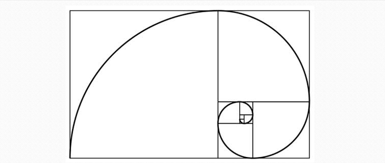

Representación gráfica de la serie de Fibonacci

```python
# Se construye la serie mediante la utilización de datos en parejas, una de las capacidades de Python.
def fibonacci(n):
    '''
    Serie de Fibonacci
    '''
    a, b = 0,1
    while a < n:
        print(a, end=' ')
        a, b = b, a+b
    print()
```

Evaluando ejemplos obtenemos.

```python
fibonacci(5)
```

```
## 0 1 1 2 3
```

```python
fibonacci(100)
```

```
## 0 1 1 2 3 5 8 13 21 34 55 89
```

En el ejemplo la secuencia se va enviado a consola, veamos un ejemplo en una lista.

```python
def Fibonacci(n):
  '''
  Serie de Fibonacci
  '''
  result=[]
  a, b = 0,1
  while a < n:
      result.append(a)
      a, b = b, a+b
  return result

serie=Fibonacci(5)
print(serie)
```

```
## [0, 1, 1, 2, 3]
```

```python
serie1=Fibonacci(100)
print(serie1)
```

```
## [0, 1, 1, 2, 3, 5, 8, 13, 21, 34, 55, 89]
```